# Data Science Project - A Review of the Relationship Between Personal Factors and Measured Blood Pressure

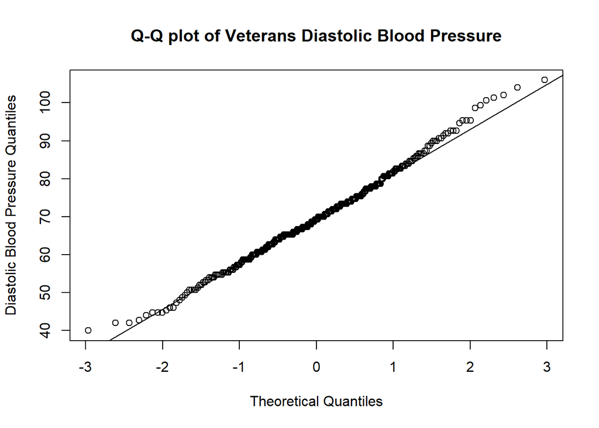

```r
qqnorm(Veterans_test$DiastolAvg, main="Q-Q plot of Veterans Diastolic Blood Pressure", ylab = "Diastolic Blood Pressure Quantiles")
qqline(Veterans_test$DiastolAvg)
```

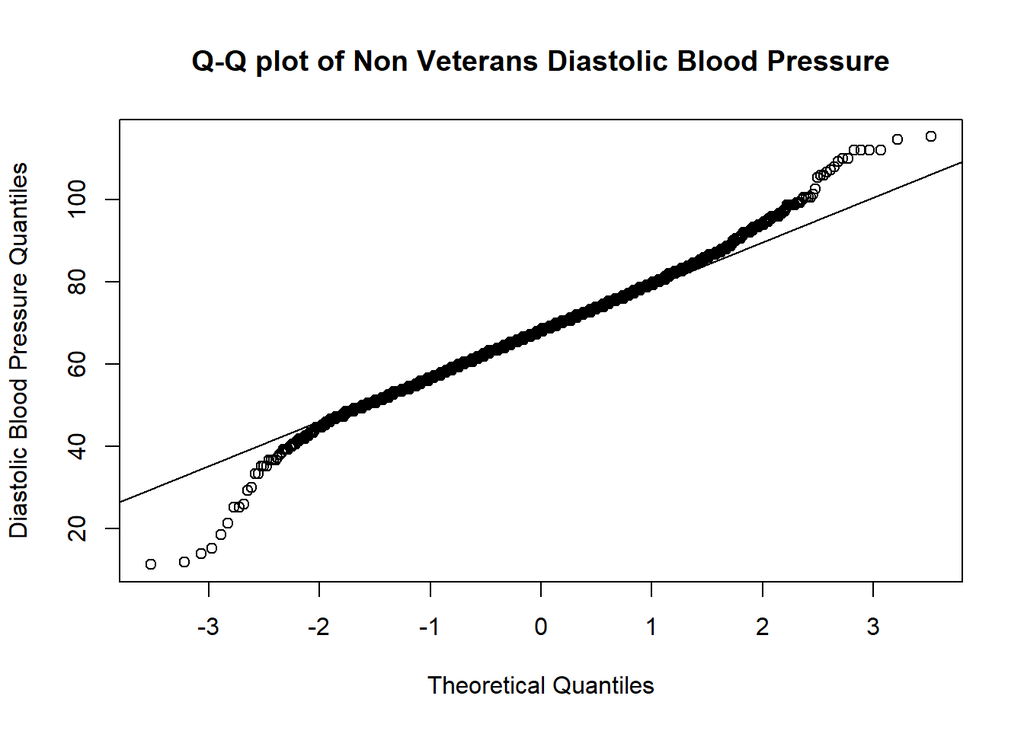

```r
qqnorm(Non_Veterans_test$DiastolAvg, main="Q-Q plot of Non Veterans Diastolic Blood Pressure", ylab = "Diastolic Blood Pressure Quantiles")
qqline(Non_Veterans_test$DiastolAvg)
```

The QQ-Plots for the Veterans and Non-Veterans are as follows:

1. Veteran Systolic Blood Pressure - There appears that there is a normal distribution but it fades off at the end of the data points.
2. Non Veterans Systolic Blood Pressure - This is the less normally distributed graph out of all 4 graphs. The end of the distribution is far above the distribution line compared to the rest of the data.
3. Veterans Diastolic Blood Pressure - This graph is the most normally distributed graph out of all the 4 graphs.
4. Non Veterans Diastolic Blood Pressure - This is a fairly normally distributed graph but the ends go off from the distribution line.

The QQ-plots are showing more normally distributed in all but the non veterans systolic blood pressure. This goes along with the histogram graphs above where the histogram for the non veterans systolic is skewed more to the right. We will now use the Shapiro-Wilk Normality Test to see if these results are accurate.

The Shapiro-Wilk Normality Test probablity values for each genders systolic and diastolic pressure distributions are given below:

For Veterans:

The Diastolic Pressure Probabality Value: 0.178

For Non Veterans:

The null hypothesis is that the two samples carry the same average.

## 9.6 Do the Categories have equivalent Blood Pressures (T-Tests for Binary Categories)

We will now try the two-sample t-test:

```r
ttest_Vet = t.test(Veterans_test$SystolAvg, Veterans_test$DiastolAvg)
ttest_Vet
```

```
##
##  Welch Two Sample t-test
##
## data:  Veterans_test$SystolAvg and Veterans_test$DiastolAvg
## t = 47, df = 567, p-value <2e-16
## alternative hypothesis: true difference in means is not equal to 0
## 95 percent confidence interval:
##  56.0 60.8
## sample estimates:
## mean of x mean of y
##     128.1      69.7
```

```r
ttest_NonVet = t.test(Non_Veterans_test$SystolAvg, Non_Veterans_test$DiastolAvg)
ttest_NonVet
```

```
##
##  Welch Two Sample t-test
##
## data:  Non_Veterans_test$SystolAvg and Non_Veterans_test$DiastolAvg
## t = 117, df = 4134, p-value <2e-16
## alternative hypothesis: true difference in means is not equal to 0
## 95 percent confidence interval:
##  51.9 53.7
## sample estimates:
## mean of x mean of y
##     121.0      68.2
```

The systolic average for veterans are 128.1, 69.7 respectively. The two-sample t-test shows a small p-value of 3.61e-198, thereby rejected the null with the means at $\alpha$ = 0.05 (or even 0.005).

The null hypothesis is that the two samples carry the same average. The systolic and diastolic blood pressures are independent of each other.

# 10 The Effect of Age on Blood Pressure (presented by Siwei Wang)

Select the subsets with `Age` between 18 and 30, 30 and 50, elder than 50 separately.

```r
loadPkg("ggplot2")
loadPkg("faraway")
loadPkg("modelr")
Sub18_30 <- dataSubset[(dataSubset$RIDAGEYR>=18)&(dataSubset$RIDAGEYR<30),]
Sub30_50 <- dataSubset[(dataSubset$RIDAGEYR>=30)&(dataSubset$RIDAGEYR<50),]
Sub50 <- dataSubset[dataSubset$RIDAGEYR>=50,]
testdf18_30 = Sub18_30[,c("SystolAvg","DiastolAvg","RIDAGEYR")]
testdf30_50 = Sub30_50[,c("SystolAvg","DiastolAvg","RIDAGEYR")]
testdf50 = Sub50[,c("SystolAvg","DiastolAvg","RIDAGEYR")]
```

Use dataframe function to make all the varibales numerical before doing the correlation test. # Correction test

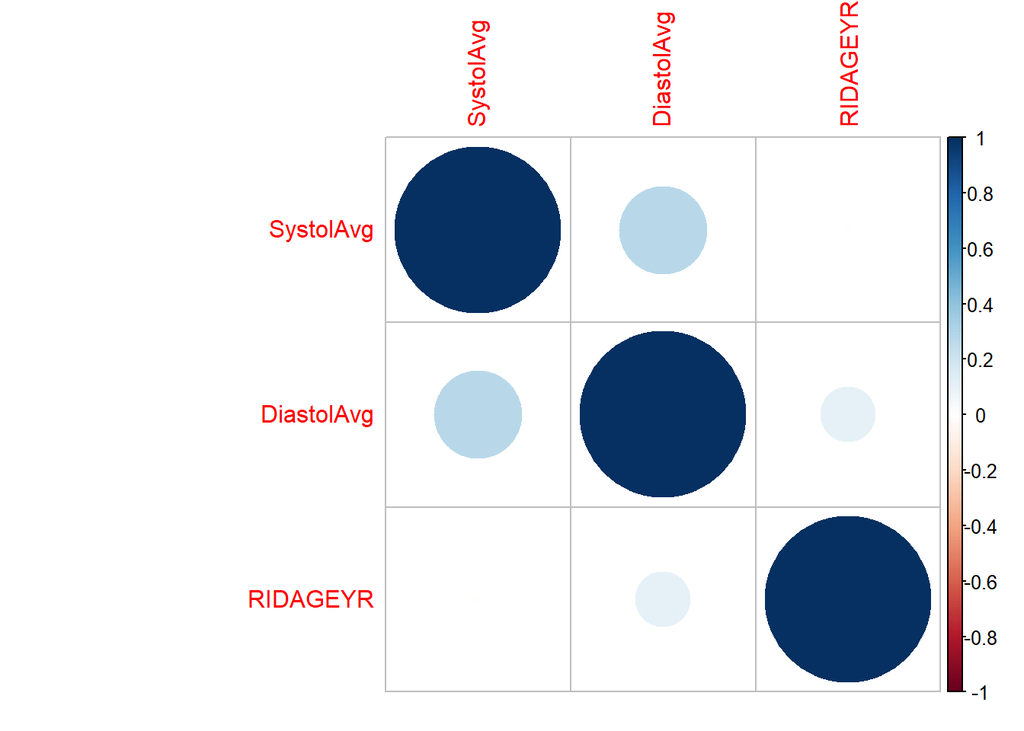

```r
loadPkg("corrplot")
testdf18_30cor = cor(testdf18_30)
#testdf18_30
corrplot(testdf18_30cor)
```

```r
# corrplot (matrix)
```

From the corrplot above, we can easily see that the relationship between blood pressure and people aged 18 to 30 are not significant.

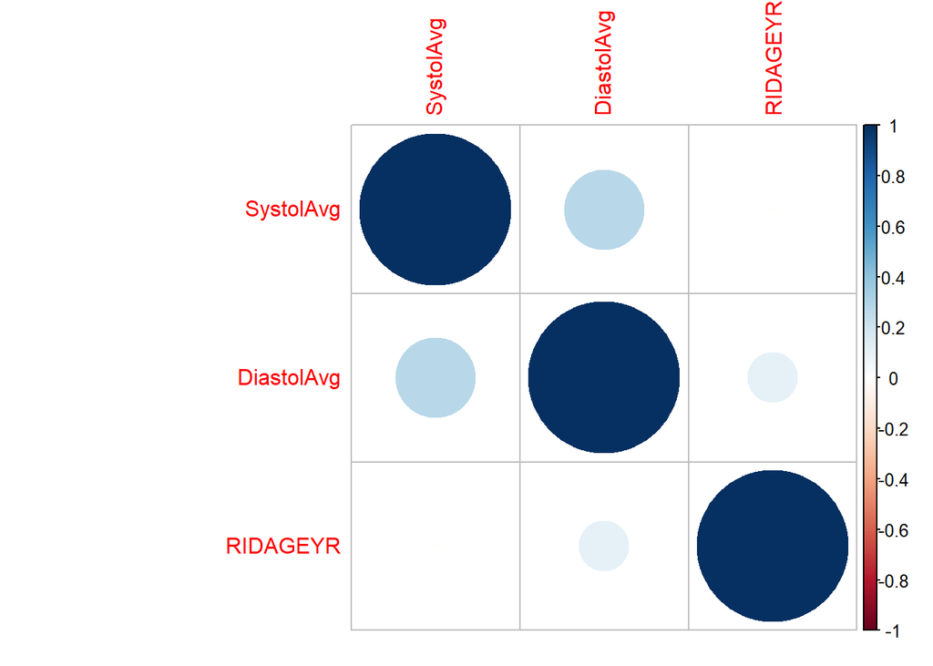

```r
testdf30_50cor = cor(testdf30_50)
#testdf18_30
corrplot(testdf18_30cor)
```

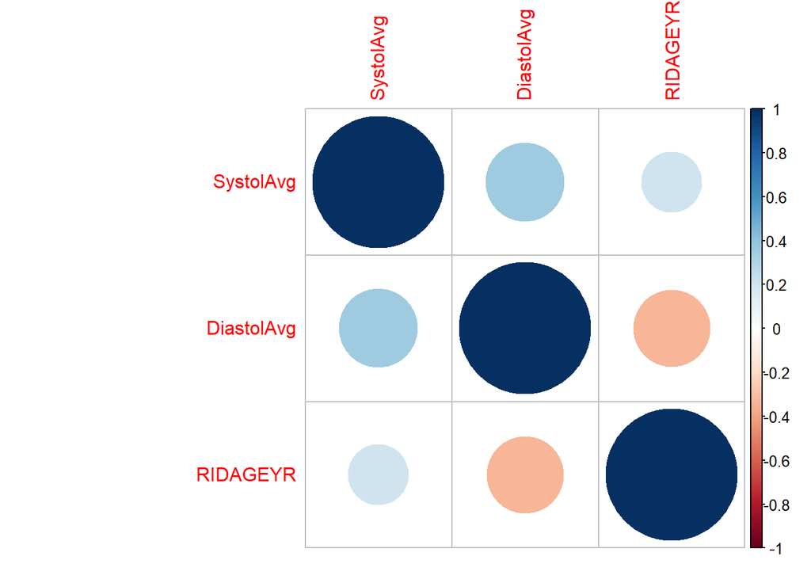

```r
testdf50cor = cor(testdf50)
#testdf50
corrplot(testdf50cor)
```

```r
fit1 <- lm(SystolAvg ~ ageGroup, data =dataSubset)
summary(fit1)
```

```
##
## Call:
## lm(formula = SystolAvg ~ ageGroup, data = dataSubset)
##
## Residuals:
##    Min     1Q Median     3Q    Max
## -60.57 -11.17  -1.57   8.83 136.43
##
## Coefficients:
##                Estimate Std. Error t value Pr(>|t|)
## (Intercept)     133.572      0.461   289.6   <2e-16 ***
## ageGroupmiddle  -15.058      0.713   -21.1   <2e-16 ***
## ageGroupyoung   -20.405      0.725   -28.1   <2e-16 ***
## ---
## Signif. codes:  0 '***' 0.001 '**' 0.01 '*' 0.05 '.' 0.1 ' ' 1
##
## Residual standard error: 17.5 on 3454 degrees of freedom
## Multiple R-squared:  0.207,  Adjusted R-squared:  0.207
## F-statistic:  451 on 2 and 3454 DF,  p-value: <2e-16
```

```r
# vif(fit1)
```

I divide the blood pressure into two groups as before, which are systolic average blood pressure and diastolic blood pressure. In this chunk, we mainly discuss age groups whether have an effect on systolic blood pressure. The model is simple as we can see because we only have one varibale inside. The middle-aged people will have 15.058 smaller systolic average blood pressure than the old. Yonger people, in the meantime expected to have 20.405 smaller systolic average blood pressure. This is not a model to some extent. I would rather call this some descriptive statistics. I also make some plots that can easily explain the relationship between two varibales.

```r
fit2 <- lm(DiastolAvg ~ ageGroup, data =dataSubset)
summary(fit2)
```

```
##
## Call:
## lm(formula = DiastolAvg ~ ageGroup, data = dataSubset)
##
## Residuals:
##    Min     1Q Median     3Q    Max
## -57.71  -7.34   0.29   7.63  54.29
##
## Coefficients:
##                Estimate Std. Error t value Pr(>|t|)
## (Intercept)      69.706      0.331   210.6  < 2e-16 ***
## ageGroupmiddle    2.302      0.512     4.5  7.1e-06 ***
## ageGroupyoung    -6.366      0.520   -12.2  < 2e-16 ***
## ---
## Signif. codes:  0 '***' 0.001 '**' 0.01 '*' 0.05 '.' 0.1 ' ' 1
##
## Residual standard error: 12.6 on 3454 degrees of freedom
## Multiple R-squared:  0.0698, Adjusted R-squared:  0.0693
## F-statistic:  130 on 2 and 3454 DF,  p-value: <2e-16
```

```r
# vif(fit1)
```

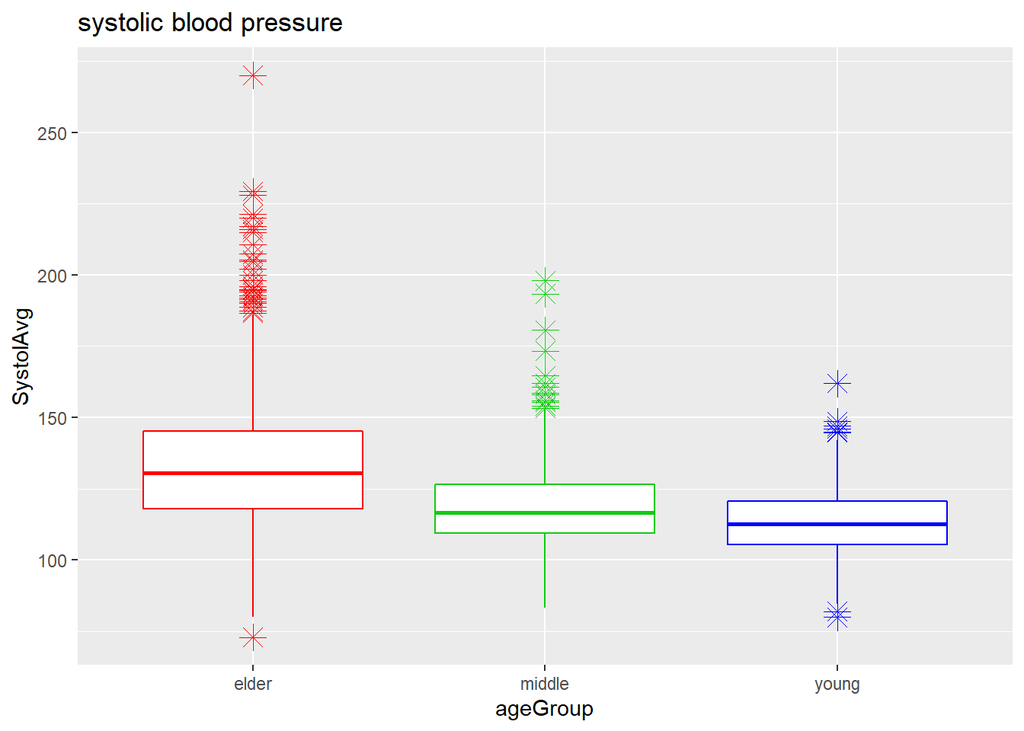

```r
# plot( SystolAvg ~ ageGroup, data = dataSubset)
# boxplot(SystolAvg~ageGroup,data=dataSubset,main="Sys", xlab="AgeGroup", ylab="GRE")
loadPkg("ggplot2")
ggplot(dataSubset, aes(x=ageGroup, y=SystolAvg)) +
  geom_boxplot( colour=c("#ff0000","#11cc11","#0000ff"), outlier.shape=8, outlier.size=4) + labs(title="systolic blood pressure", x="ageGroup", y = "SystolAvg")
```

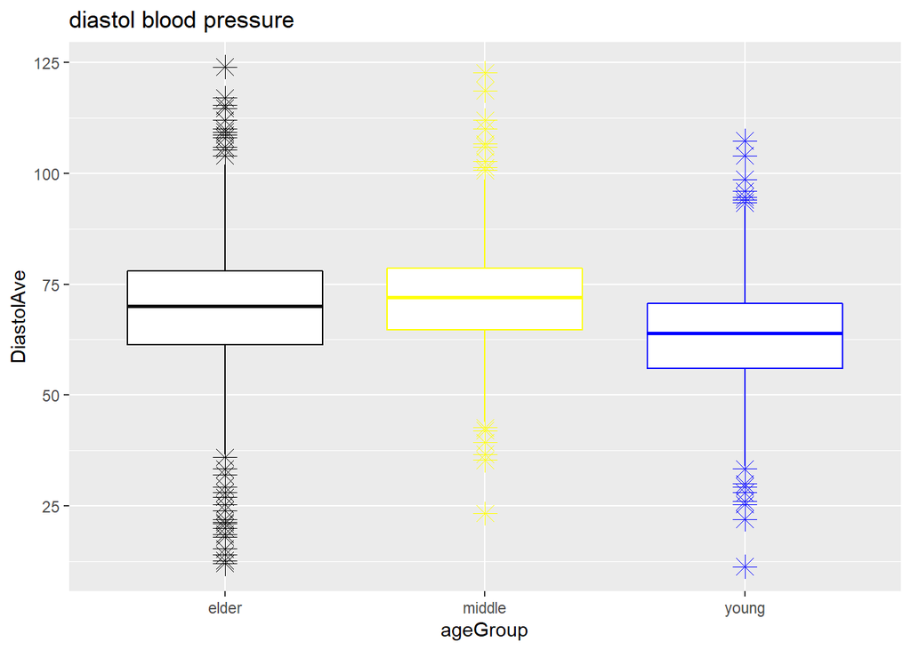

```r
ggplot(dataSubset, aes(x=ageGroup, y=DiastolAvg)) +
  geom_boxplot( colour=c('black','yellow','blue'), outlier.shape=8, outlier.size=4) + labs(title="diastol blood pressure", x="ageGroup", y = "DiastolAve")
```

```r
# plot(fit1)
```

Here, we also use two blood pressure groups. For systolic average blood pressure, older people are observed to have higher blood pressure than the other two groups. Middle aged people have a little bit higher blood pressure than the young. For diastolic blood pressure, 30-50 aged people seem to have higher blood presurre than people more than 50. Younger people are still with lowest blood pressure.

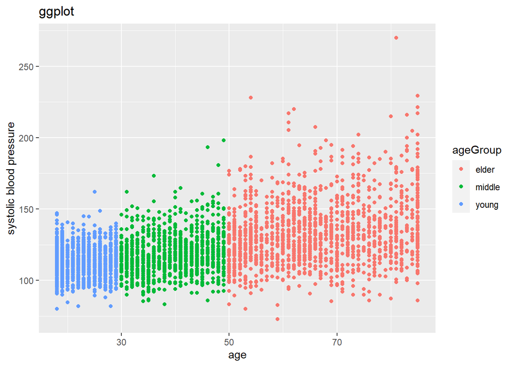

```r
loadPkg("ggplot2")
ggplot(data=dataSubset, aes(x=RIDAGEYR, y=SystolAvg, color=ageGroup )) +
  geom_point( outlier.shape=8, outlier.size=4 ) +
  labs(title="ggplot", x="age", y = "systolic blood pressure")
```

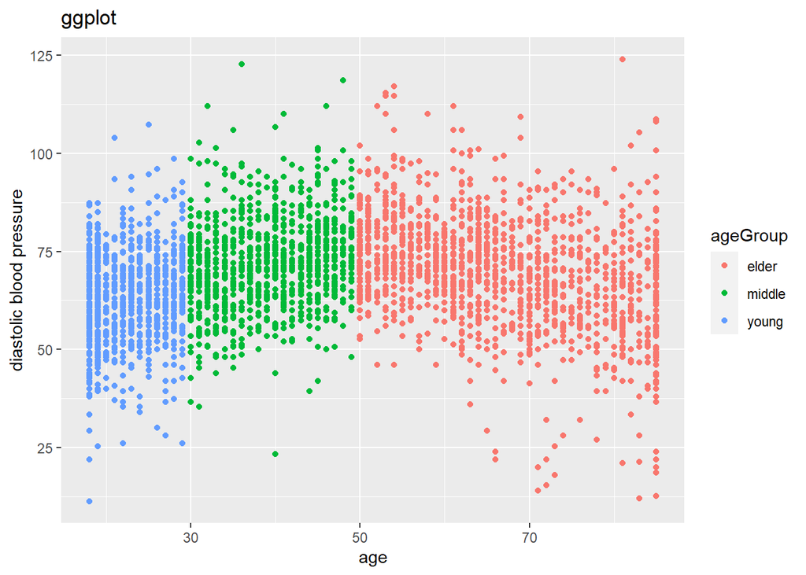

```r
ggplot(data=dataSubset, aes(x=RIDAGEYR, y=DiastolAvg, color=ageGroup )) +
  geom_point( outlier.shape=8, outlier.size=4 ) +
  labs(title="ggplot", x="age", y = "diastolic blood pressure")
```

The results are shown the same as we mentioned before. The points are much easier to see the elder peole will have higher systolic average blood pressure than the other two groups. The middle aged people actually have less difference with younger people. The diastolic blood pressure, there is actually not that much difference bewteen different aged people.

# 11 The Effect of Annual Household Income on Blood Pressure (presented by Juhne Zhang)

My expectation is that people with higher annual household income would have healthier blood pressure status. The reason I make this expectation is because eatting healthy is more expensive. Usually people would spend similar amount of money from their annual household income for food, which means people with higher household income would be more likely to consider eatting healthy food because they can afford it. Therefore, they would have higher chance of getting healthier blood pressure status.

## 11.1 Visual Presentation of Data (Bar-graph)

The dataframe I use has seven variables, I am interested in the relationship between American family annual household income and their blood pressures. There are two different type of blood pressures, Diastolic blood pressures and Systolic blood pressures. They are the two indicaters to measure your blood pressure. The below table shows top five row in the dataframe.

```r
#read
df_HHI <- data.frame(dataSubset)
#display top 5
head(df_HHI,5)
```

```
##     SEQN SystolAvg DiastolAvg RIAGENDR RIDAGEYR           RIDRETH1 DMQMILIT
## 5  31131       139       73.3   Female       44 Non-Hispanic Black       No
## 6  31132       131       57.3     Male       70 Non-Hispanic White      Yes
## 8  31134       120       67.3     Male       73 Non-Hispanic White      Yes
## 12 31139       111       65.3   Female       18     Other Hispanic       No
## 17 31144       116       72.7     Male       21     Other Hispanic       No
##              INDHHINC ageGroup
## 5    $75,000 and Over   middle
## 6    $75,000 and Over    elder
## 8        Over $20,000    elder
## 12   $75,000 and Over    young
## 17 $10,000 to $14,999    young
```

```r
dim(df_HHI)
```

```
## [1] 3457    9
```

To be more confident about our data, the next thing I did is identify and removing the outliers. This can increase the accuracy of the plots we are going to draw. In other word, to make our final results more reliable. The graphs below show that their are too many outliers and have a serious bad influence on the dataset. After removing the outliers, the graphs above tend to be better scaled with normal distribution.

```r
#remove outlier

df_HHI = outlierKD2(df_HHI, SystolAvg, TRUE)
```

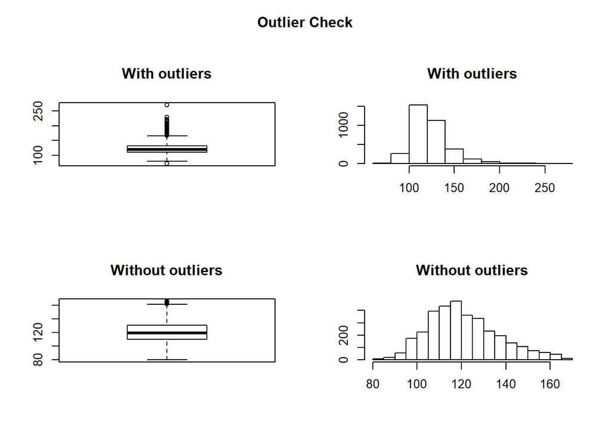

```
## Outliers identified: 123
## Propotion (%) of outliers: 3.7
## Mean of the outliers: 183
## Mean without removing outliers: 123
## Mean if we remove outliers: 121
## Outliers successfully removed
```

```r
df_HHI = outlierKD2(df_HHI, DiastolAvg, TRUE)
```

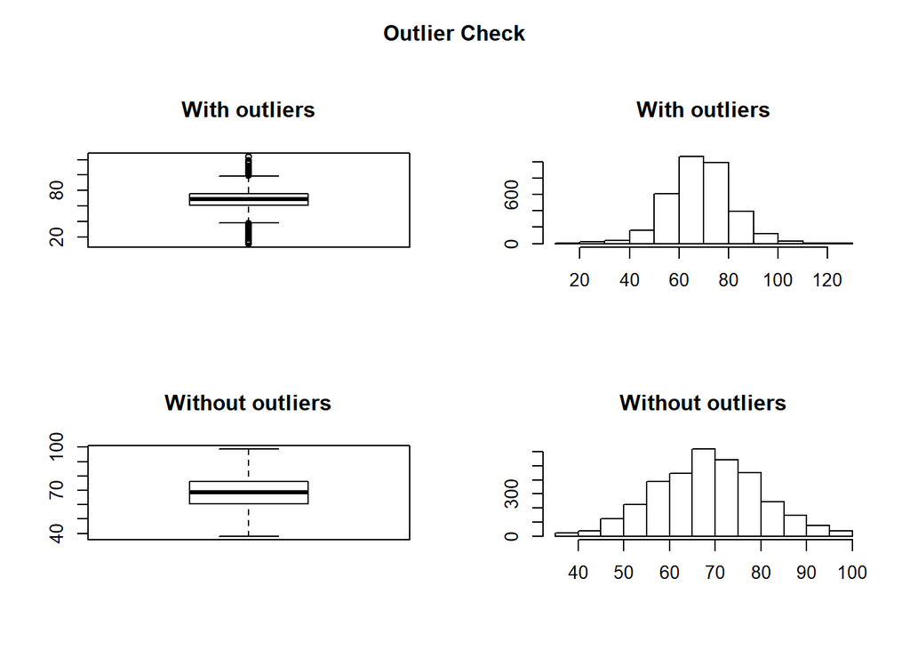

```
## Outliers identified: 89
## Propotion (%) of outliers: 2.6
## Mean of the outliers: 65.4
## Mean without removing outliers: 68.6
## Mean if we remove outliers: 68.7
## Outliers successfully removed
```

```r
dim(df_HHI)
```

```
## [1] 3457    9
```

## 11.2 test normality

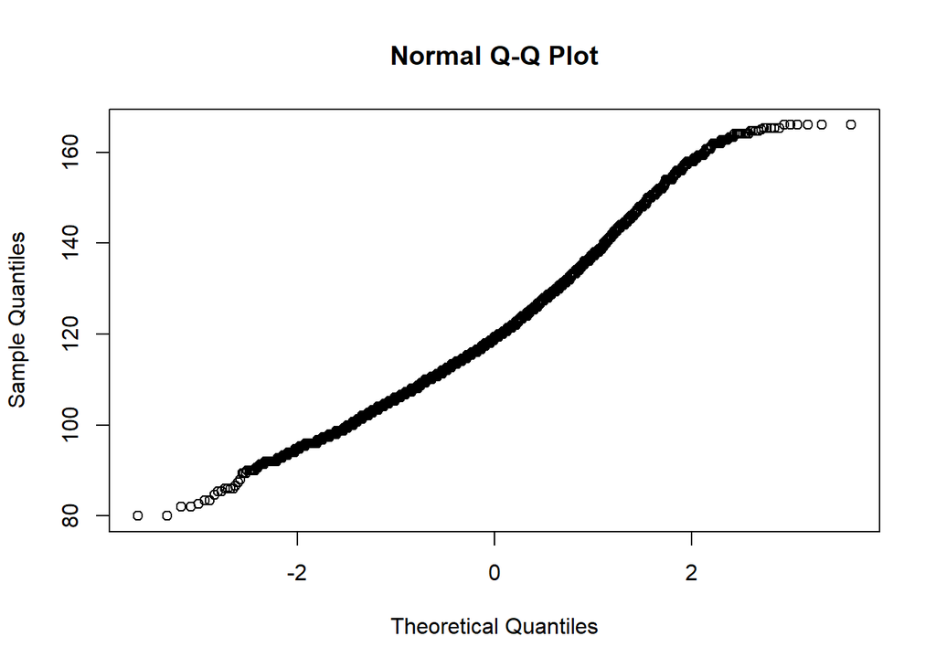

```r
qqnorm(df_HHI$SystolAvg)
```

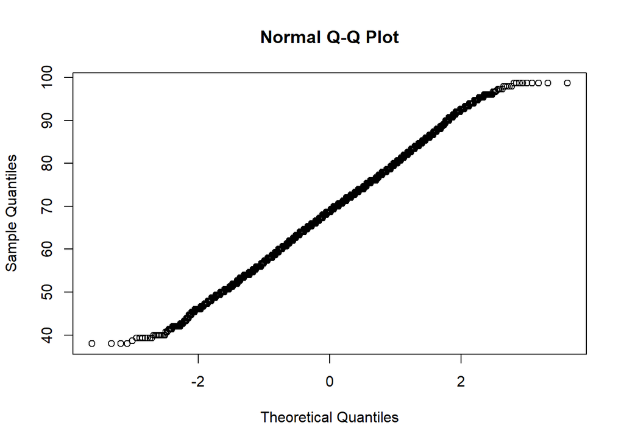

```r
qqnorm(df_HHI$DiastolAvg)
```

Then, I want to know the numebr of patients in each categories and decide if make sample on categories. I build a frequency table for each category and notice that category $7,5000 and above and too many data points. It might because that patients did not want to reveal their actual annual household income. All the other categories seem to have good frequency, which followed a normal distribution.

```r
#read household dataset
#df_HHI <- read.csv('./datasets/dataset_INDHHINC_l/INDHHINC_l.csv')
#df_HHI <- data.frame(dataSubset)
#display top 5
#head(df_HHI,5)
#remove Don't know ...
#dim(df_HHI)[1]
df_HHI <- subset(df_HHI, ! INDHHINC %in% c('Don\'t know', 'Over $20,000', 'Refused', 'Under $20,000'))
#df_HHI[df_HHI[,'INDHHINC'] == 'Over $20,000',]
#dim(df_HHI)[1]
#remove na
#dim(df_HHI)[1]
df_HHI <- df_HHI[complete.cases(df_HHI),]
#head(df_HHI[rowSums(is.na(df_HHI))>0,])
#dim(df_HHI)[1]
#get number of diff categorical value under household
df_HHI$INDHHINC <- factor(df_HHI$INDHHINC)
HH_cats <- levels(df_HHI$INDHHINC)
#HH_cats
#get frequency
HH_freq <- table(df_HHI$INDHHINC)
df_HH_freq <- as.data.frame(HH_freq)
df_HH_freq
```

```
##                  Var1 Freq
## 1      $ 0 to $ 4,999   78
## 2  $ 5,000 to $ 9,999  153
## 3  $10,000 to $14,999  241
## 4  $15,000 to $19,999  235
## 5  $20,000 to $24,999  244
## 6  $25,000 to $34,999  416
## 7  $35,000 to $44,999  321
## 8  $45,000 to $54,999  311
## 9  $55,000 to $64,999  205
## 10 $65,000 to $74,999  182
## 11   $75,000 and Over  686
```

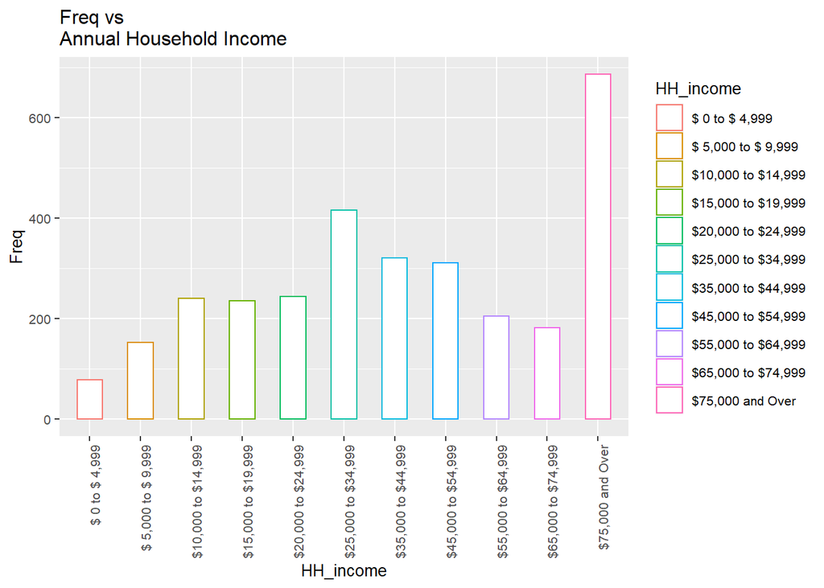

```r
#rename frequency df columns
colnames(df_HH_freq) <- c('HH_income','Freq')
#
#names(df_HH_freq)
ggplot(data=df_HH_freq, aes(x=HH_income, y=Freq, color=HH_income)) +
  geom_bar(stat='identity', width=0.5, fill = 'white') +
    theme(text = element_text(size=10),
        axis.text.x = element_text(angle=90, hjust=1)) +
    ggtitle('Freq vs \nAnnual Household Income')
```

## 11.3 Systolic and Diastolic Pressures with Respect to Each Category (Histograms and Shapiro Normality Test)

### 11.3.1 get mean of Systolic and Diastolic blood pressure average

In order to show the relationship between each category and blood pressure, I need to build a table with each category’s mean blood pressure.

```r
mean_avg_sys_dia <- df_HHI %>%
              group_by(INDHHINC) %>%
              summarise(SystolAvg = mean(SystolAvg),
                        DiastolAvg = mean(DiastolAvg)
                        )
mean_avg_sys_dia
```

```
## # A tibble: 11 x 3
##    INDHHINC           SystolAvg DiastolAvg
##    <fct>                  <dbl>      <dbl>
##  1 $ 0 to $ 4,999          118.       65.1
##  2 $ 5,000 to $ 9,999      124.       67.9
##  3 $10,000 to $14,999      121.       66.7
##  4 $15,000 to $19,999      122.       67.5
##  5 $20,000 to $24,999      123.       67.9
##  6 $25,000 to $34,999      123.       68.6
##  7 $35,000 to $44,999      121.       67.7
##  8 $45,000 to $54,999      124.       68.7
##  9 $55,000 to $64,999      119.       69.5
## 10 $65,000 to $74,999      119.       70.0
## 11 $75,000 and Over        119.       70.2
```

### 11.3.2 convert numerical HH_income

I also need to convert the factor into corresponding numerical value so that cor.test function can be applied.

```r
numer.INDHHINC <- as.numeric(mean_avg_sys_dia$INDHHINC)
mean_avg_sys_dia$DiastolAvg
```

```
##  [1] 65.1 67.9 66.7 67.5 67.9 68.6 67.7 68.7 69.5 70.0 70.2
```

```r
numer.INDHHINC
```

```
##  [1]  1  2  3  4  5  6  7  8  9 10 11
```

### 11.3.3 display correlation between mean average blood presure according to annual household income

The scatter plot shows that most Systolic blood pressure data points have their mean on the center and less data points distributed on both sides under each category. This tells that the blood pressure data points under each category is normally distributed.

Since the annual household income is ordinal, I find that Systolic blood pressure have a negative correlation with annual household income. The accual correlation between them is -0.254, which support this idea. This test shows that the population with higher annual household income will have relatively lower Systolic blood pressure, and vice versa.

According to American national health organization, having Systolic blood pressure above 120 is a signal for high blood pressure. This negative correlation shows that people with lower annual household income are more likely to have high blood pressure. On the other hand, most people with Systolic blood pressure higher than 120 are from the first half part of the annual household income which is below $3,5000.

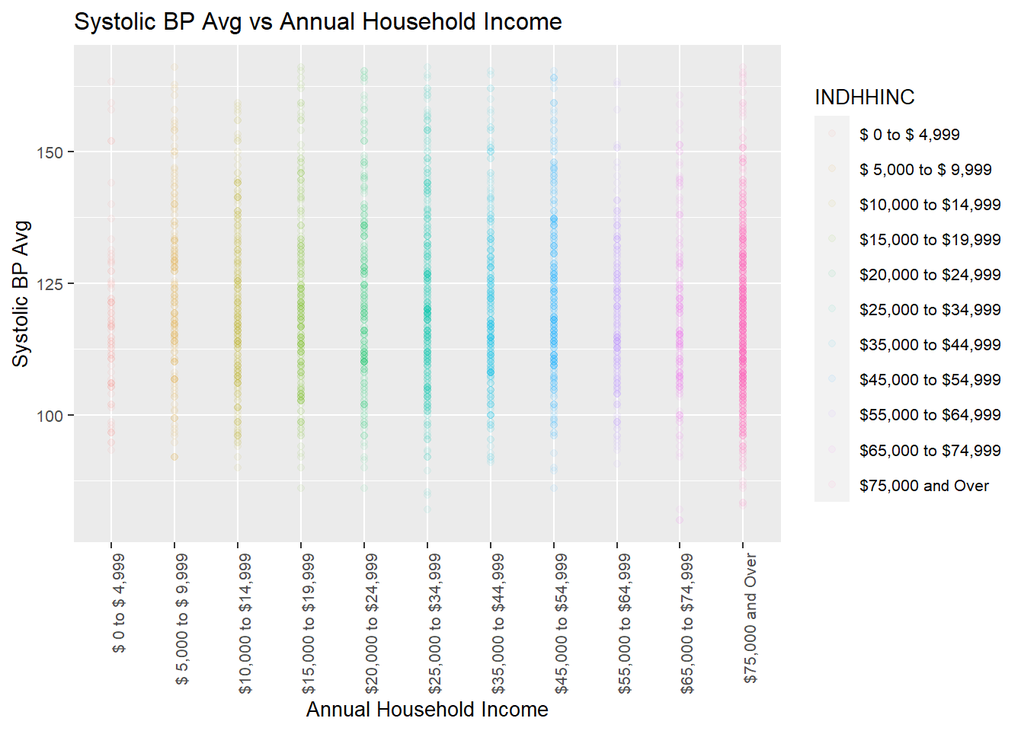

```r
#annual household systolic scatter plot
ggplot(df_HHI, aes(x=INDHHINC, y=SystolAvg, color=INDHHINC)) +
  geom_point(alpha = .05) +
  theme(text = element_text(size=10),
        axis.text.x = element_text(angle=90, hjust=1)) +
  ggtitle('Systolic BP Avg vs Annual Household Income') +
  ylab('Systolic BP Avg') +
  xlab('Annual Household Income')
```

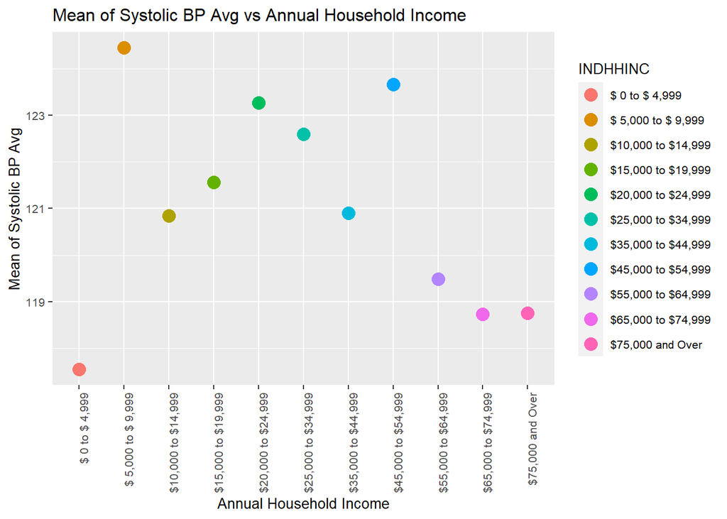

```r
#plot systolic mean for each category
ggplot(mean_avg_sys_dia, aes(x=INDHHINC, y=SystolAvg, color=INDHHINC)) +
  geom_point(size = 4) +
  theme(text = element_text(size=10),
        axis.text.x = element_text(angle=90, hjust=1)) +
  ggtitle('Mean of Systolic BP Avg vs Annual Household Income') +
  ylab('Mean of Systolic BP Avg') +
  xlab('Annual Household Income')
```

```r
#get corelation
cor(numer.INDHHINC, mean_avg_sys_dia$SystolAvg, method = 'pearson')
```

```
## [1] -0.254
```

```r
#mean vector for each cat
avg_sys <- c()
#calculate mean for Sys
for(cat in HH_cats){
  #append mean for each cat
  avg_sys <- c(avg_sys, mean(df_HHI[df_HHI$INDHHINC == cat,2], na.rm=TRUE))
}
```

The scatter plot shows that most Diastolic blood pressure data points have their mean on the center and less data points distributed on both sides under each category. This tells that the Diastolic blood pressure data points under each category is normally distributed.

On the other hand, the Diastolic blood pressure correlation test shows a positive relation with the annual household income. The correlation is 0.903, which is a very significant positive correlation. In other word, the higher the annual house hold income the higher their Diastolic blood pressure.

Although, the graph shows a positive correlation between Diastolic blood pressure and annual household income, the average Diastolic blood pressure for the second half of the group which is annual household income above $3,5000 are still lower than 80, which is within the healthy Diastolic blood pressure range release by the American national health organization.

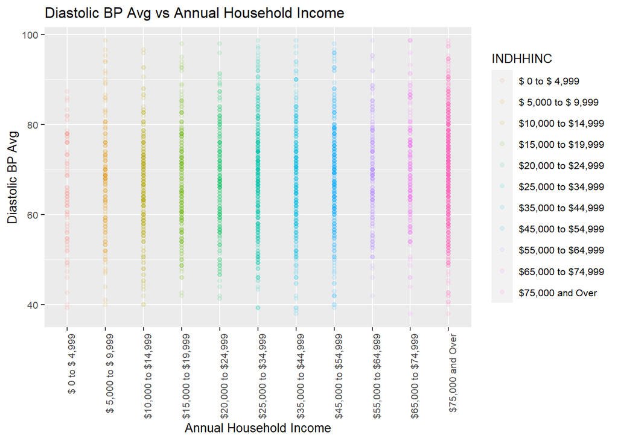

```r
#annual household Diastolic scatter plot
ggplot(df_HHI, aes(x=INDHHINC, y=DiastolAvg, color=INDHHINC)) +
  geom_point(alpha = 0.1) +
  theme(text = element_text(size=10),
        axis.text.x = element_text(angle=90, hjust=1)) +
  ggtitle('Diastolic BP Avg vs Annual Household Income') +
  ylab('Diastolic BP Avg') +
  xlab('Annual Household Income')
```

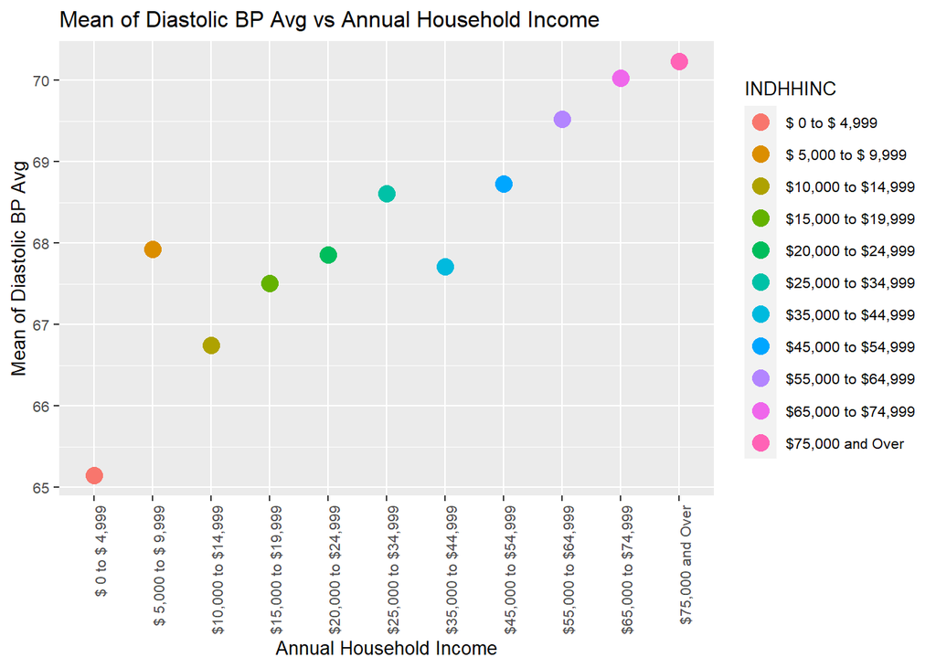

```r
#plot Diastolic mean for each category
ggplot(mean_avg_sys_dia, aes(x=INDHHINC, y=DiastolAvg, color=INDHHINC)) +
  geom_point(size = 4) +
  theme(text = element_text(size=10),
        axis.text.x = element_text(angle=90, hjust=1)) +
  ggtitle('Mean of Diastolic BP Avg vs Annual Household Income') +
  ylab('Mean of Diastolic BP Avg') +
  xlab('Annual Household Income')
```

```r
#get corelation
cor(numer.INDHHINC, mean_avg_sys_dia$DiastolAvg, method = 'pearson')
```

```
## [1] 0.903
```

## 11.4 Do the Categories have equivalent Blood Pressures (Box Plots and T-Tests for Binary Categories and ANOVA Test for multiple Categories)

The Systolic BP Avg vs Annual Household Income boxplot shows that the mean Systolic blood pressure for each category does not vary too much from each other, this makes common sense since human blood pressure is within this range.

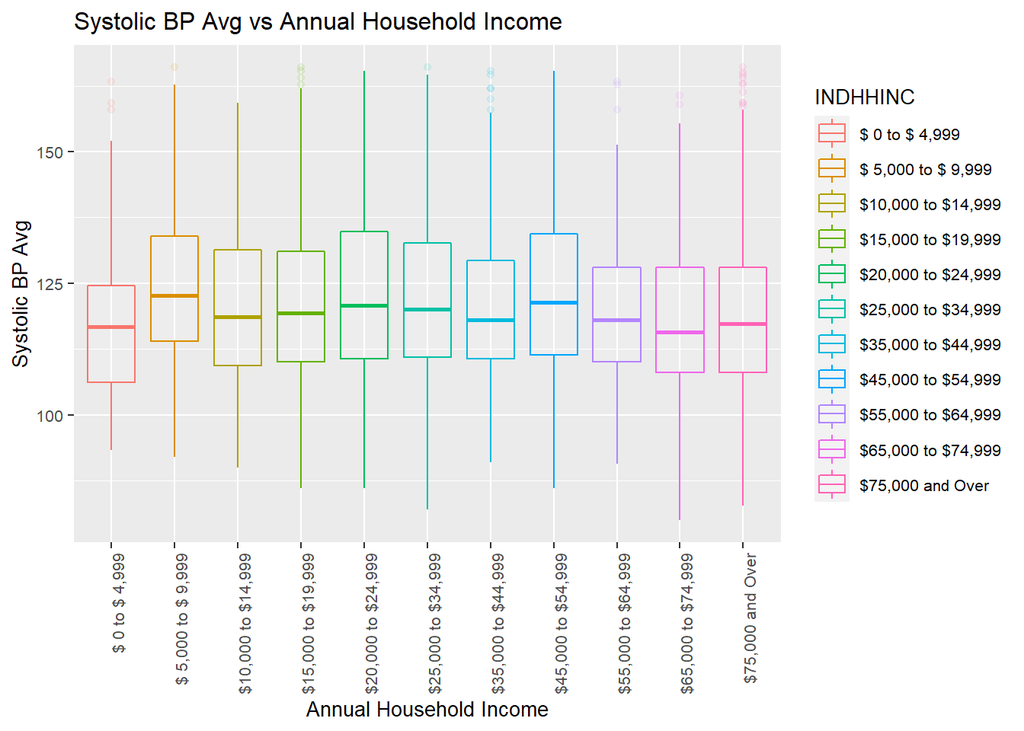

```r
#boxplot for systolic avg vs household
ggplot(df_HHI, aes(x=INDHHINC, y=SystolAvg, color=INDHHINC)) +
  geom_boxplot(alpha = 0.1) +
  theme(text = element_text(size=10),
        axis.text.x = element_text(angle=90, hjust=1)) +
  ggtitle('Systolic BP Avg vs Annual Household Income') +
  ylab('Systolic BP Avg') +
  xlab('Annual Household Income')
```

## 11.5 anova test for systolic blood pressure vs annual household income

The anova test and tukey test for Systolic blood pressure shows that high annual household income categories have different Systolic blood pressure means with low annual household income. This result shows that annual household income do have effect on Systolic blood pressure.

```r
sys_aov = aov(SystolAvg ~ INDHHINC, data = df_HHI)
summary.aov(sys_aov)
```

```
##               Df Sum Sq Mean Sq F value  Pr(>F)
## INDHHINC      10  12197    1220    5.03 2.7e-07 ***
## Residuals   3061 742217     242
## ---
## Signif. codes:  0 '***' 0.001 '**' 0.01 '*' 0.05 '.' 0.1 ' ' 1
```

```r
tukey_sys_AoV <- TukeyHSD(sys_aov)
#tukey_sys_AoV
tukey_sys_AoV$INDHHINC[tukey_sys_AoV$INDHHINC[,4]<0.05,4]
```

```
## $65,000 to $74,999-$ 5,000 to $ 9,999   $75,000 and Over-$ 5,000 to $ 9,999
##                              0.033536                              0.002221
##   $75,000 and Over-$20,000 to $24,999   $75,000 and Over-$25,000 to $34,999
##                              0.004940                              0.003678
## $65,000 to $74,999-$45,000 to $54,999   $75,000 and Over-$45,000 to $54,999
##                              0.028905                              0.000225
```

The Diastolic BP Avg vs Annual Household Income boxplot shows that the mean Systolic blood pressure for each category does not vary too much from each other, this makes common sense since human blood pressure is within this range.

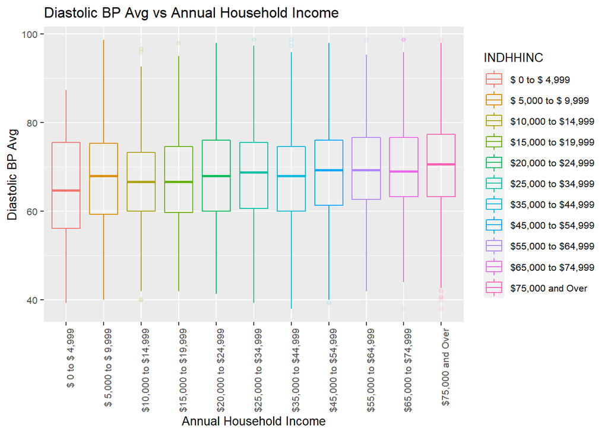

```r
#
ggplot(df_HHI, aes(x=INDHHINC, y=DiastolAvg, color=INDHHINC)) +
  geom_boxplot(alpha = 0.1) +
  theme(text = element_text(size=10),
        axis.text.x = element_text(angle=90, hjust=1)) +
  ggtitle('Diastolic BP Avg vs Annual Household Income') +
  ylab('Diastolic BP Avg') +
  xlab('Annual Household Income')
```

The anova test and tukey test for Diastolic blood pressure shows that high annual household income categories have different Diastolic blood pressure means with low annual household income. This result shows that annual household income do have effect on Diastolic blood pressure.

```r
dia_aov = aov(DiastolAvg ~ INDHHINC, data = df_HHI)
summary.aov(dia_aov)
```

```
##               Df Sum Sq Mean Sq F value  Pr(>F)
## INDHHINC      10   4865     486    3.88 2.9e-05 ***
## Residuals   3061 383443     125
## ---
## Signif. codes:  0 '***' 0.001 '**' 0.01 '*' 0.05 '.' 0.1 ' ' 1
```

```r
tukey_dia_AoV <- TukeyHSD(dia_aov)
tukey_dia_AoV$INDHHINC[tukey_dia_AoV$INDHHINC[,4]<0.05,4]
```

```
##     $75,000 and Over-$ 0 to $ 4,999 $75,000 and Over-$10,000 to $14,999
##                             0.00692                             0.00168
## $75,000 and Over-$35,000 to $44,999
##                             0.03558
```

## 11.6 Healthy blood pressure frequency plot for each category

Finally, I need to conform my expectation that people with higher annual household income would have healthier blood pressure status. The healthy blood pressure indicators that release by American national health organization is Systolic blood pressure below 120 and Diastolic blood pressure below 80.

To get the healthy blood pressure proportion for each category, I need to first filter out the patients with Systolic blood pressure under 120 and Diastolic blood pressure under 80 and then build a frequency table with it. Finally, use the healthy frequency table divide by total frequency table to get the healthy proportion table.

```r
df_HHI_healthy <- df_HHI[df_HHI$DiastolAvg<=80  & df_HHI$SystolAvg <= 120,]
dim(df_HHI_healthy)
```

```
## [1] 1567    9
```

```r
HH_healthy_freq <- table(df_HHI_healthy$INDHHINC)

df_HHI_healthy <- as.data.frame(HH_healthy_freq)
#rename frequency df columns
colnames(df_HHI_healthy) <- c('HH_income','healthy_Freq')
head(df_HHI_healthy)
```

```
##            HH_income healthy_Freq
## 1     $ 0 to $ 4,999           47
## 2 $ 5,000 to $ 9,999           65
## 3 $10,000 to $14,999          126
## 4 $15,000 to $19,999          121
## 5 $20,000 to $24,999          112
## 6 $25,000 to $34,999          210
```

```r
head(df_HH_freq)
```

```
##            HH_income Freq
## 1     $ 0 to $ 4,999   78
## 2 $ 5,000 to $ 9,999  153
## 3 $10,000 to $14,999  241
## 4 $15,000 to $19,999  235
## 5 $20,000 to $24,999  244
## 6 $25,000 to $34,999  416
```

```r
df_healthy_total <- merge(df_HH_freq, df_HHI_healthy, by='HH_income')
#head(df_healthy_total)
df_healthy_total <- df_healthy_total %>% as_tibble() %>% mutate(
  proportion = healthy_Freq / Freq
)
head(df_healthy_total)
```

```
## # A tibble: 6 x 4
##   HH_income           Freq healthy_Freq proportion
##   <fct>              <int>        <int>      <dbl>
## 1 $ 0 to $ 4,999        78           47      0.603
## 2 $ 5,000 to $ 9,999   153           65      0.425
## 3 $10,000 to $14,999   241          126      0.523
## 4 $15,000 to $19,999   235          121      0.515
## 5 $20,000 to $24,999   244          112      0.459
## 6 $25,000 to $34,999   416          210      0.505
```

```r
df_order_healthy_total <- df_healthy_total[order(df_healthy_total$proportion),]
head(df_order_healthy_total)
```

```
## # A tibble: 6 x 4
##   HH_income           Freq healthy_Freq proportion
##   <fct>              <int>        <int>      <dbl>
## 1 $ 5,000 to $ 9,999   153           65      0.425
## 2 $20,000 to $24,999   244          112      0.459
## 3 $45,000 to $54,999   311          144      0.463
## 4 $25,000 to $34,999   416          210      0.505
## 5 $15,000 to $19,999   235          121      0.515
## 6 $35,000 to $44,999   321          166      0.517
```

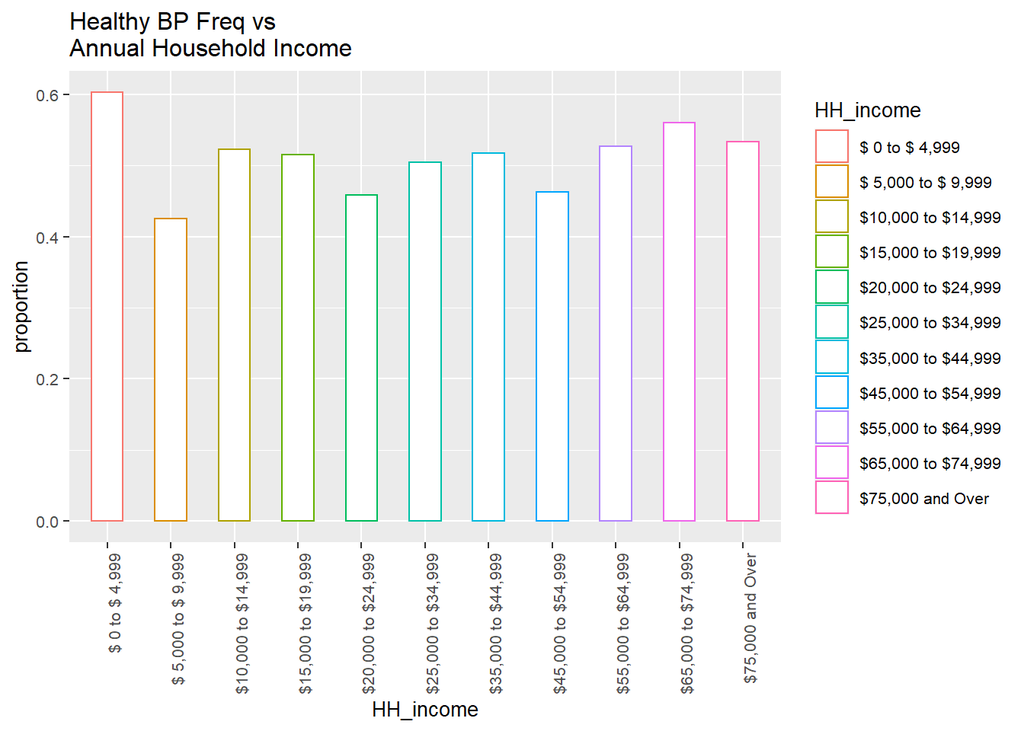

```r
#names(HH_healthy_freq)
ggplot(data=df_healthy_total, aes(x=HH_income, y=proportion, color=HH_income)) +
  geom_bar(stat='identity', width=0.5, fill = 'white') +
    theme(text = element_text(size=10),
        axis.text.x = element_text(angle=90, hjust=1)) +
    ggtitle('Healthy BP Freq vs \nAnnual Household Income')
```

## 11.7 linear regression model test

### 11.7.1 Sytolic blood pressure vs annual household income and Diastolic blood pressure

```r
loadPkg("modelr")
model.HHI <- lm(SystolAvg ~ INDHHINC+DiastolAvg, data = df_HHI)
summary(model.HHI)
```

```
##
## Call:
## lm(formula = SystolAvg ~ INDHHINC + DiastolAvg, data = df_HHI)
##
## Residuals:
##    Min     1Q Median     3Q    Max
## -35.43 -10.46  -2.07   8.46  54.17
##
## Coefficients:
##                            Estimate Std. Error t value Pr(>|t|)
## (Intercept)                 81.9102     2.2133   37.01   <2e-16 ***
## INDHHINC$ 5,000 to $ 9,999   5.3753     1.9933    2.70    0.007 **
## INDHHINC$10,000 to $14,999   2.4212     1.8658    1.30    0.194
## INDHHINC$15,000 to $19,999   2.7181     1.8720    1.45    0.147
## INDHHINC$20,000 to $24,999   4.2384     1.8636    2.27    0.023 *
## INDHHINC$25,000 to $34,999   3.1471     1.7687    1.78    0.075 .
## INDHHINC$35,000 to $44,999   1.9466     1.8086    1.08    0.282
## INDHHINC$45,000 to $54,999   4.1485     1.8152    2.29    0.022 *
## INDHHINC$55,000 to $64,999  -0.4628     1.9077   -0.24    0.808
## INDHHINC$65,000 to $74,999  -1.4927     1.9412   -0.77    0.442
## INDHHINC$75,000 and Over    -1.5725     1.7151   -0.92    0.359
## DiastolAvg                   0.5471     0.0231   23.66   <2e-16 ***
## ---
## Signif. codes:  0 '***' 0.001 '**' 0.01 '*' 0.05 '.' 0.1 ' ' 1
##
## Residual standard error: 14.3 on 3060 degrees of freedom
## Multiple R-squared:  0.168,  Adjusted R-squared:  0.165
## F-statistic: 56.3 on 11 and 3060 DF,  p-value: <2e-16
```

```r
coef(model.HHI)
```

```
##                (Intercept) INDHHINC$ 5,000 to $ 9,999
##                     81.910                      5.375
## INDHHINC$10,000 to $14,999 INDHHINC$15,000 to $19,999
##                      2.421                      2.718
## INDHHINC$20,000 to $24,999 INDHHINC$25,000 to $34,999
##                      4.238                      3.147
## INDHHINC$35,000 to $44,999 INDHHINC$45,000 to $54,999
##                      1.947                      4.149
## INDHHINC$55,000 to $64,999 INDHHINC$65,000 to $74,999
##                     -0.463                     -1.493
##   INDHHINC$75,000 and Over                 DiastolAvg
##                     -1.573                      0.547
```

```r
confint(model.HHI)
```

```
##                             2.5 % 97.5 %
## (Intercept)                77.571 86.250
## INDHHINC$ 5,000 to $ 9,999  1.467  9.284
## INDHHINC$10,000 to $14,999 -1.237  6.080
## INDHHINC$15,000 to $19,999 -0.952  6.389
## INDHHINC$20,000 to $24,999  0.584  7.893
## INDHHINC$25,000 to $34,999 -0.321  6.615
## INDHHINC$35,000 to $44,999 -1.600  5.493
## INDHHINC$45,000 to $54,999  0.589  7.708
## INDHHINC$55,000 to $64,999 -4.203  3.278
## INDHHINC$65,000 to $74,999 -5.299  2.313
## INDHHINC$75,000 and Over   -4.935  1.790
## DiastolAvg                  0.502  0.592
```

```r
model.HHI.pred <- add_predictions(df_HHI,model.HHI)
head(model.HHI.pred)
```

```
##     SEQN SystolAvg DiastolAvg RIAGENDR RIDAGEYR           RIDRETH1 DMQMILIT
## 5  31131       139       73.3   Female       44 Non-Hispanic Black       No
## 6  31132       131       57.3     Male       70 Non-Hispanic White      Yes
## 12 31139       111       65.3   Female       18     Other Hispanic       No
## 17 31144       116       72.7     Male       21     Other Hispanic       No
## 23 31150       137       75.3     Male       79 Non-Hispanic White      Yes
## 24 31151       139       72.7   Female       59 Non-Hispanic Black       No
##              INDHHINC ageGroup pred
## 5    $75,000 and Over   middle  120
## 6    $75,000 and Over    elder  112
## 12   $75,000 and Over    young  116
## 17 $10,000 to $14,999    young  124
## 23 $10,000 to $14,999    elder  126
## 24 $35,000 to $44,999    elder  124
```

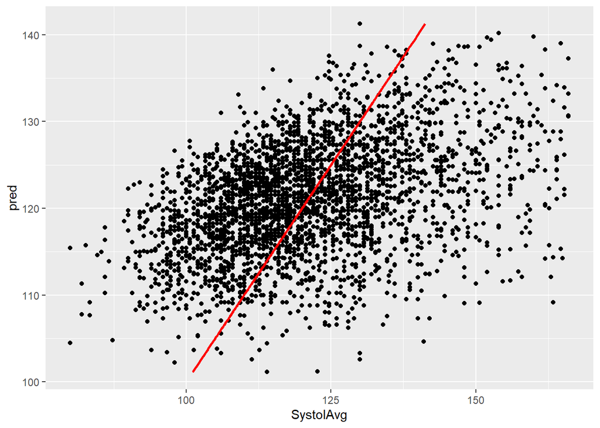

```r
ggplot(model.HHI.pred,aes(SystolAvg,pred))+geom_point(aes(SystolAvg,pred))+geom_line(aes(pred), colour="red", size=1)
```

```r
loadPkg("modelr")
model.HHI <- lm(DiastolAvg ~ INDHHINC+SystolAvg, data = df_HHI)
summary(model.HHI)
```

```
##
## Call:
## lm(formula = DiastolAvg ~ INDHHINC + SystolAvg, data = df_HHI)
##
## Residuals:
##    Min     1Q Median     3Q    Max
## -35.39  -6.40   0.47   7.25  29.17
##
## Coefficients:
##                            Estimate Std. Error t value Pr(>|t|)
## (Intercept)                 31.9267     1.8249   17.49  < 2e-16 ***
## INDHHINC$ 5,000 to $ 9,999   0.8297     1.4343    0.58  0.56298
## INDHHINC$10,000 to $14,999   0.6684     1.3414    0.50  0.61831
## INDHHINC$15,000 to $19,999   1.2266     1.3458    0.91  0.36214
## INDHHINC$20,000 to $24,999   1.0883     1.3405    0.81  0.41696
## INDHHINC$25,000 to $34,999   2.0358     1.2714    1.60  0.10943
## INDHHINC$35,000 to $44,999   1.6137     1.2999    1.24  0.21454
## INDHHINC$45,000 to $54,999   1.8570     1.3054    1.42  0.15497
## INDHHINC$55,000 to $64,999   3.8285     1.3695    2.80  0.00521 **
## INDHHINC$65,000 to $74,999   4.5456     1.3930    3.26  0.00111 **
## INDHHINC$75,000 and Over     4.7392     1.2299    3.85  0.00012 ***
## SystolAvg                    0.2826     0.0119   23.66  < 2e-16 ***
## ---
## Signif. codes:  0 '***' 0.001 '**' 0.01 '*' 0.05 '.' 0.1 ' ' 1
##
## Residual standard error: 10.3 on 3060 degrees of freedom
## Multiple R-squared:  0.165,  Adjusted R-squared:  0.162
## F-statistic: 55.1 on 11 and 3060 DF,  p-value: <2e-16
```

```r
coef(model.HHI)
```

```
##                (Intercept) INDHHINC$ 5,000 to $ 9,999
##                     31.927                      0.830
## INDHHINC$10,000 to $14,999 INDHHINC$15,000 to $19,999
##                      0.668                      1.227
## INDHHINC$20,000 to $24,999 INDHHINC$25,000 to $34,999
##                      1.088                      2.036
## INDHHINC$35,000 to $44,999 INDHHINC$45,000 to $54,999
##                      1.614                      1.857
## INDHHINC$55,000 to $64,999 INDHHINC$65,000 to $74,999
##                      3.829                      4.546
##   INDHHINC$75,000 and Over                  SystolAvg
##                      4.739                      0.283
```

```r
confint(model.HHI)
```

```
##                             2.5 % 97.5 %
## (Intercept)                28.349 35.505
## INDHHINC$ 5,000 to $ 9,999 -1.983  3.642
## INDHHINC$10,000 to $14,999 -1.962  3.298
## INDHHINC$15,000 to $19,999 -1.412  3.865
## INDHHINC$20,000 to $24,999 -1.540  3.717
## INDHHINC$25,000 to $34,999 -0.457  4.529
## INDHHINC$35,000 to $44,999 -0.935  4.163
## INDHHINC$45,000 to $54,999 -0.703  4.417
## INDHHINC$55,000 to $64,999  1.143  6.514
## INDHHINC$65,000 to $74,999  1.814  7.277
## INDHHINC$75,000 and Over    2.328  7.151
## SystolAvg                   0.259  0.306
```

```r
model.HHI.pred <- add_predictions(df_HHI,model.HHI)
head(model.HHI.pred)
```

```
##     SEQN SystolAvg DiastolAvg RIAGENDR RIDAGEYR           RIDRETH1 DMQMILIT
## 5  31131       139       73.3   Female       44 Non-Hispanic Black       No
## 6  31132       131       57.3     Male       70 Non-Hispanic White      Yes
## 12 31139       111       65.3   Female       18     Other Hispanic       No
## 17 31144       116       72.7     Male       21     Other Hispanic       No
## 23 31150       137       75.3     Male       79 Non-Hispanic White      Yes
## 24 31151       139       72.7   Female       59 Non-Hispanic Black       No
##              INDHHINC ageGroup pred
## 5    $75,000 and Over   middle 76.0
## 6    $75,000 and Over    elder 73.6
## 12   $75,000 and Over    young 67.9
## 17 $10,000 to $14,999    young 65.4
## 23 $10,000 to $14,999    elder 71.2
## 24 $35,000 to $44,999    elder 72.9
```

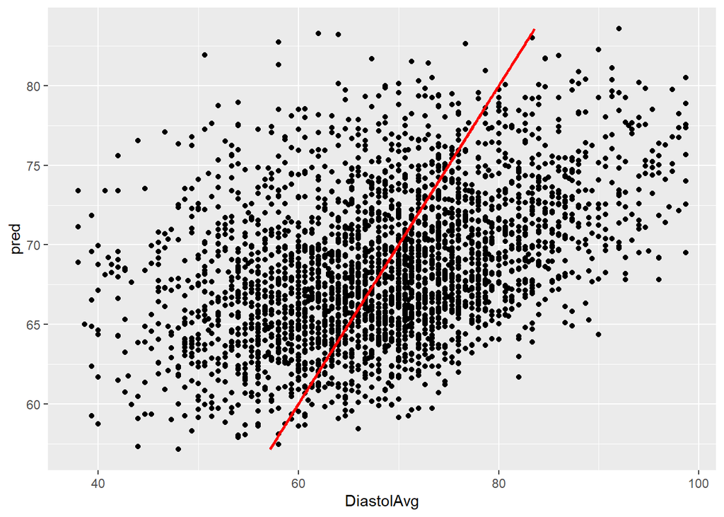

```r
ggplot(model.HHI.pred,aes(DiastolAvg,pred))+geom_point(aes(DiastolAvg,pred))+geom_line(aes(pred), colour="red", size=1)
```